# History of Tornadoes in South Carolina 1950-2018

Brandon Vaughan

Data concerning tornado frequencies were pulled from the database at the [National Oceanic and Atmospheric Administration Storm Events database](https://www.ncdc.noaa.gov/stormevents/).

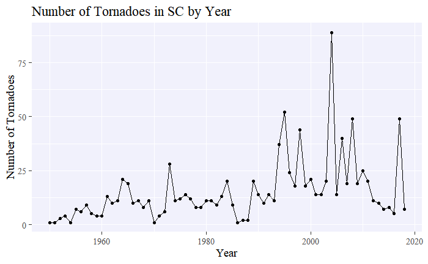

[figure not shown]

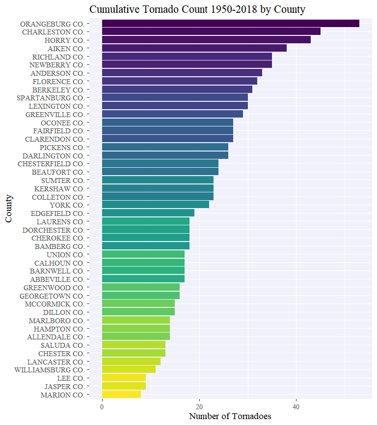

Another way to inspect this is a heatmap of the cumulative tornado county over a map of South Carolina. This graph is interactive, so hold your mouse over a county to see its name and tornado count!

[interactive chart not shown]

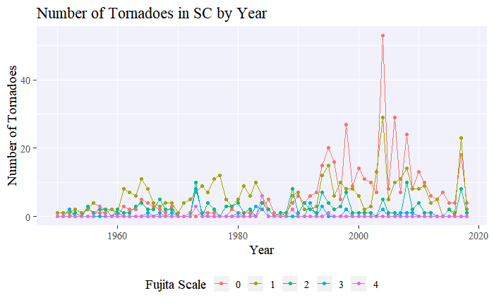

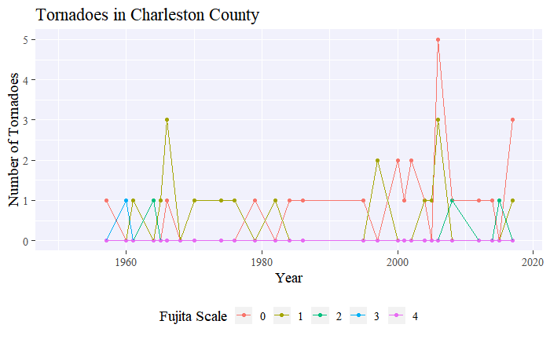

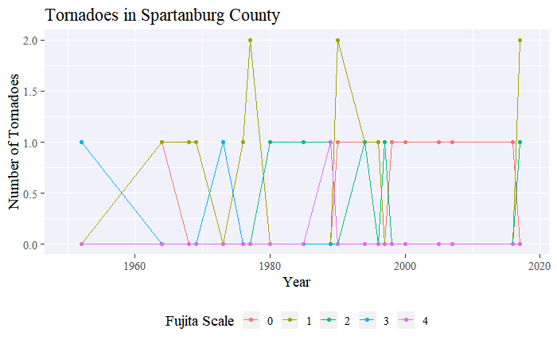

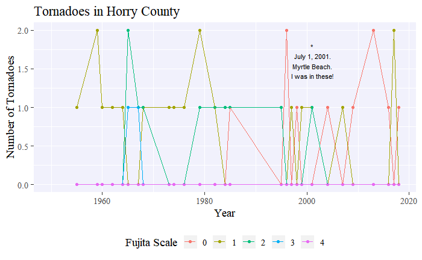

Next, it might be natural to wonder how global climate drives the number of tornadoes experienced each year in South Carolina. To explore this question three variables of interest were be entered into a generalized additive model. The first variable is the global temperature fluctuation (globalTemp), which chracterizes the change in global temperature over time. This variable is of primary interest because it pertains to global warming effects. The second variable included is the yearly average Oceanic Niño Index (ONI), which records the effects of El Nino (greater than average sea surface temperature) and La Nina (lower than average sea surface temperature). This data was gathered from [National Weather Service Climate Prediction Center](https://origin.cpc.ncep.noaa.gov/products/analysis_monitoring/ensostuff/ONI_v5.php). It is important to note that the ONI is adjusted for global warming trends, so ONI will not be confounded by globalTemp (see [this link for more information](https://origin.cpc.ncep.noaa.gov/products/analysis_monitoring/ensostuff/ONI_change.shtml) ). Last, the number of sunspots recorded in each year were gathered from [the Australian Government Space Weather Services](https://www.sws.bom.gov.au/Educational/2/3/6) because sunspots are known to affect weather patterns. Because of this an interaction term between globalTemp and sunspots was also included in the model.

It is important to note that the generalized additive model is not the same as a generalized linear model. The GAM models non-linear interactions between predictors and an outcome variable. Hence, a simple linear regression would model $\text{Outcome} \sim \text{Intercept} + \sum_i \text{Predictor}_i \cdot \text{Coefficient}_i$ while the generalized additive model instead models the outcome as a linear combination of potentially non-linear functions of each predictor, ie, $\text{Outcome} \sim \text{Intercept} +\sum_i f\text{(Predictor)}_i$. Penalized cyclic (appropriate for time series with potentially cyclical patterns) b-splines (cp basis spines in the mgcv R package used to fit the model) were used to find these non-linear functions. Finally, a poisson family with identity link function were used due to the outcome being a count variable (number of tornadoes).

Below is an ANOVA table of the model showing the statistical significance of each predictor and interaction. Also shown are partial dependence plots (pdps) with individual conditional expectation (ice) curves for the main effect of each predictor. The pdp shows the marginal effects of each predictor on the predicted outcome (J. H. Friedman 2001). The prediction function is fixed at the values of the predictor and averaged over the other features. The ice curves visualize the dependence of the predicted response for each observation of a predictor separately, which yields an impression of how sensitive the prediction is to values of the predictor.

| term | ANOVA Table edf | ANOVA Table ref.df | ANOVA Table statistic | ANOVA Table p.value | VSMPR |
| --- | --- | --- | --- | --- | --- |
| s(globalTemp) | 2.892 | 3 | 183.774 | 0.000 | ≥ 1000 |
| s(YrlyONI) | 0.000 | 3 | 0.000 | 0.384 | 1 |
| s(Sunspots) | 2.468 | 3 | 74.715 | 0.000 | ≥ 1000 |
| ti(globalTemp,Sunspots) | 4.541 | 9 | 23.273 | 0.000 | ≥ 1000 |

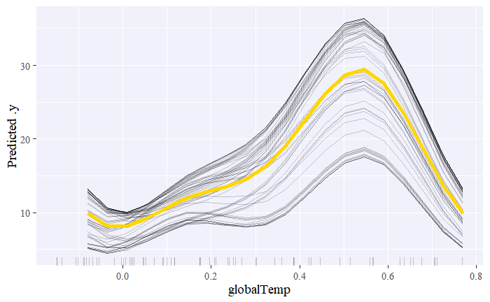

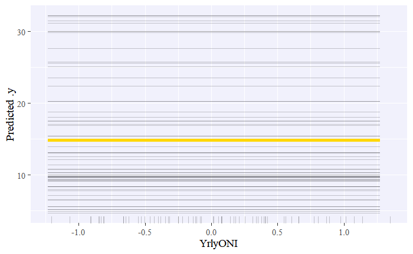

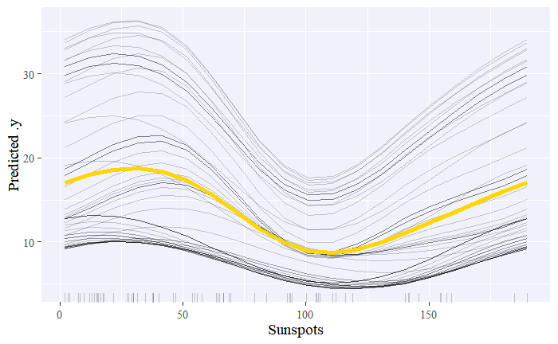

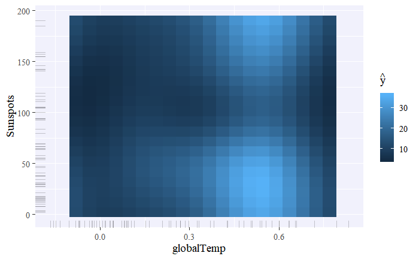